# A Class of Their Own: Housing Characteristics of Small and Mid-Size Cities

NYU Furman Center

2021-01-27

The analysis presented here appears in the blog post [*Housing Characteristics of Small and Mid-Sized Cities*](https://furmancenter.org/thestoop/entry/housing-characteristics-of-small-and-mid-sized-cities)

#### Add libraries and formats

```r
library(tidyverse) # general data manipulation and graphing
library(reshape2)
library(lubridate) # format dates
library(scales) # number formatting
library(janitor) # data cleaning
library(hrbrthemes)
library(gt) # formatting tables
library(tidycensus) # pulling in census data
library(jsonlite)
library(ggplot2) # making graphs
library(acssf)
library(ggrepel)


# Creating a color blind friendly palette using https://colorbrewer2.org/#type=diverging&scheme=BrBG&n=4
city_size_pal <- c(
  "#a6611a",
  "#dfc27d",
  "#018571",
  "#80cdc1"
)
```

## Defining External Variables

We utilize Bureau of Labor Statistics’ Consumer Price Index (CPI) factor to normalize rents between 2000 and 2019. To access 2000 Decennial data, we use the US Census Bureau’s API, which requires an access key.

```r
### CPI (Consumer Price Index) to adjust for inflation between 2000 and 2019
#Add inflation factor: 2000 rents in 2019 dollars (source: https://www.bls.gov/data/inflation_calculator.htm)
CPI <- 1.49118 # Change the CPI to represent the studied years using the bls inflation calculator.

### Census API Key
# Input your census API key below to access the census data. You can sign-up for a key here:https://api.census.gov/data/key_signup.html
census_api_key = "c32dfbf7d25fe9558fd11bf021780457970f96ff"
```

## Data Pull

#### 5-Year American Community Survey (ACS) Data 2015-2019

For this blog post we use the American Community Survey 5-year estimate data for 2015 to 2019.

```r
# Searching census codes
v19 <- load_variables(2019, "acs5", cache = TRUE)

# Pull in census variables
census_2019 <- get_acs(
  geography = "place",
  year = 2019,
  survey = "acs5",
  output = "wide",
  geometry = FALSE,
  moe_sum = FALSE,
  variables = c(
    "B01003_001E", # pop_num,
    "B03002_006E", # pop_race_asian_num
    "B03002_004E", # pop_race_black_num
    "B03002_012E", # pop_race_hisp_num
    "B03002_003E", # pop_race_white_num
    acs_vars("B01001_{c(3:6, 27:30)*}E"), # pop_u18_num
    acs_vars("B01001_{c(20:25, 44:49)*}E"), # pop_65p_num
    acs_vars("B01001_{c(7:19, 31:43)*}E"),
    "B17001_002E", # pop_pov_num
    "B25002_002E", # unit_occ_num
    "B25003_002E", # unit_occ_own_num
    "B25003_003E", # unit_occ_rent_num
    "B25063_002E", # unit_rent_cash_num
    acs_vars("B25070_{7:10*}E"), # rent_burden_num
    "B25002_001E", # unit_num
    "B25002_003E", # unit_vac_num
    "B25064_001E", # rent_gross_med
    "B25119_001E", # hh_inc_med
    "B25070_010E", # rent_burden_sev_num
    "B19025_001E", # aggregate_hh_income
    "B17001_001E", # pop_pov_denom_num
    "B19025_001E", # aggregate_hh_income_est
    "B19001_001E", # hh_income_count_est summary variable
    "B25024_001E", # total_units
    "B25024_002E", # total_1_det
    "B25024_003E", # total_1_att
    "B25032_013E", #    total_units_rent
    "B25032_014", # units_rent_1_det
    "B25032_015E", # units_rent_1_att
    "B25106_025E", # count_less20K_est
    "B25106_028E", # cost_burden_less20K_est
    "B25106_029E", # count_20K34k_est
    "B25106_032E", # cost_burden_20K34k_est
    "B25106_033E", # count_35K49k_est
    "B25106_036E", # cost_burden_35K49k_est
    "B25106_037E", # count_50K74k_est
    "B25106_040E", # cost_burden_50K74k_est
    "B25106_041E", # count_more75k_est
    "B25106_044E", # cost_burden_more75k_est
    "B25003H_002E", # homeowner_nonHisp_white_est
    "B25003H_001E", # count_nonHisp_white_est
    "B25003B_002E", # homeowner_Black_est
    "B25003B_001E", # count_Black_est
    "B25003D_002E", # homeowner_Asian_est
    "B25003D_001E", # count_Asian_est
    "B25003I_002E", # homeowner_Latino_est
    "B25003I_001E" # count_Latino_est
  )
) %>%
  mutate(
    "pop_u18_num" = acs_est_sum("B01001_{c(3:6, 27:30)*}E"),
    "pop_65p_num" = acs_est_sum("B01001_{c(20:25, 44:49)*}E"),
    "pop_18_64_num" = acs_est_sum("B01001_{c(7:19, 31:43)*}E"),
    "rent_burden_num" = acs_est_sum("B25070_{7:10*}E")
  )
# Assign places to city size categories for the analysis
census_2019 <- census_2019 %>%
  mutate(size_type = case_when(
    B01003_001E >= 50000 & B01003_001E < 100000 ~ "small (50-100k)",
    B01003_001E >= 100000 & B01003_001E < 150000 ~ "small-mid (100-150k)",
    B01003_001E >= 150000 & B01003_001E < 500000 ~ "mid (150-500k)",
    B01003_001E >= 500000 ~ "large (500k +)"
  )) %>%
  filter(!is.na(size_type))

# Select variables needed for the analysis below
census_2019 <- census_2019 %>%
  select(
    geoid = "GEOID",
    NAME,
    pop_num =  "B01003_001E",
    pop_race_asian_num = "B03002_006E",
    pop_race_black_num = "B03002_004E",
    pop_race_hisp_num = "B03002_012E",
    pop_race_white_num  = "B03002_003E",
    pop_pov_num = "B17001_002E",
    unit_occ_num = "B25002_002E",
    unit_occ_own_num = "B25003_002E",
    unit_occ_rent_num = "B25003_003E",
    unit_rent_cash_num = "B25063_002E",
    unit_num = "B25002_001E",
    unit_vac_num = "B25002_003E",
    hh_inc_med = "B25119_001E",
    rent_burden_sev_num = "B25070_010E",
    pop_pov_denom_num = "B17001_001E",
    rent_gross_med = "B25064_001E",
    aggregate_hh_income_est = "B19025_001E",
    hh_income_count_est = "B19001_001E",
    "pop_u18_num",
    "pop_65p_num",
    "pop_18_64_num",
    "rent_burden_num",
    total_units = "B25024_001E",
    total_1_det = "B25024_002E",
    total_1_att = "B25024_003E",
    total_units_rent = "B25032_013E",
    units_rent_1_det = "B25032_014E",
    units_rent_1_att = "B25032_015E",
    count_less20K_est = "B25106_025E",
    cost_burden_less20K_est = "B25106_028E",
    count_20K34k_est = "B25106_029E",
    cost_burden_20K34k_est = "B25106_032E",
    count_35K49k_est = "B25106_033E",
    cost_burden_35K49k_est = "B25106_036E",
    count_50K74k_est = "B25106_037E",
    cost_burden_50K74k_est = "B25106_040E",
    count_more75k_est = "B25106_041E",
    cost_burden_more75k_est = "B25106_044E",
    homeowner_nonHisp_white_est = "B25003H_002E",
    count_nonHisp_white_est = "B25003H_001E",
    homeowner_Black_est = "B25003B_002E",
    count_Black_est = "B25003B_001E",
    homeowner_Asian_est = "B25003D_002E",
    count_Asian_est = "B25003D_001E",
    homeowner_Latino_est = "B25003I_002E",
    count_Latino_est = "B25003I_001E",
    "size_type"
  )

# Save as a data frame
small_mid_explore <- data.frame(census_2019)
```

## Exclude Cities

In this analysis, we drop cities that are outside of the 50-states and DC (e.g., in the US Territories). We also exclude cities that are newly established since the 2000 Census and those that merged with their county jurisdiction to form a unified government during that period as well, so that we have a consistent sample of cities for the analysis.

```r
# Dropping cities that were not included in the 2000 census, cities outside the 50-states, and those that merged with their county jurisdiction to form a unified government over the period.
small_mid_explore <- filter(small_mid_explore, ! geoid %in% c("0464210", "0621230", "0637692", "0646842", "0812815", "1200410", "1245060", "1310944", "1319000", "1342425", "1349008", "1372122", "1373784", "1571550", "2148006", "2578972", "2483775", "5103320", "5367167", "1271625", "7276770", "7206593", "7214290", "7263820", "7210334", "7232522", "7252431" ))
```

## Wrangling Data

#### 2000 Decenial Census data and principal city indicator

We pull in the 2000 5-Year American Community Survey Decennial Census Data to see how city trends have changed between 2000 and 2019.

```r
#Pull in the 2000 Decennial Census city population data
decennial_pop_num_cities <-
  fromJSON(paste0(
    "https://api.census.gov/data/2000/dec/sf1?get=P001001,NAME&for=place:*&key=", census_api_key)
  ) %>%
  as_tibble() %>%
  transmute(
    pop_num_2000 = V1,
    geo_name = V2,
    geoid = str_glue("{V3}{V4}")
  ) %>%
  filter(pop_num_2000 != "P001001")

# Joining the Decennial census data
small_mid_city_pop_comparison <- small_mid_explore %>%
  left_join(decennial_pop_num_cities, by = "geoid") %>%
  mutate(pop_num_2000 = as.numeric(pop_num_2000))

# Define placed as "principal city"  as "Principal" and those excluded as "suburbs". More on the Census designations here: https://www.census.gov/programs-surveys/metro-micro/about.html#:~:text=The%20largest%20city%20in%20each,concerning%20population%20size%20and%20employment.

principal_cities <- read_csv("metro_micro_principal_cities_2018_census.csv", n_max = 1268) %>%
  mutate(principal_city = TRUE)%>%
  mutate(
    format_zeros= str_pad(geoid, width = 7, side = "left", pad = "0") # Address leading zeros issue
  )%>%
  select(format_zeros, principal_city) %>%
  rename(geoid = format_zeros)

# Join data, and create principal and suburbs flag
small_mid_city_pop_comparison <- small_mid_city_pop_comparison %>%
    left_join(principal_cities, by = "geoid")%>%
  mutate(place_type = case_when(
    principal_city == TRUE ~ "Principal",
    is.na(principal_city) ~ "Suburbs"
  )) %>%
  mutate(place_type_flag = case_when(
    principal_city == TRUE ~ 1,
    is.na(principal_city) ~ 0
  ))
```

## Summary Statsitics Table

#### Create weighted median income and rent figures

With the exception of the median household income and gross rent figures, the following descriptive statistics were calculated by aggregating Census place estimates by city size categories and then calculating mean or percentages for the full population living in those cities. For the household income and gross rent figures, Census reporting standards limit the ability to recalculate median estimates for aggregated geographies. Rather than produce mean estimates for these variables, which are susceptible to outliers skewing the results, the household income and gross rent estimates are presented as median estimates weighted by the total number of households in a city and the total households with cash rent in a city, respectively.

```r
# Create Weighted aggregated median figures
small_mid_city_pop_comparison <- small_mid_city_pop_comparison %>%
  mutate(
    agg_med_rent = rent_gross_med * unit_rent_cash_num,# Weighted aggregated median rent
    agg_med_hh_income = hh_inc_med * hh_income_count_est # weighted aggregated median household income
  )
```

#### Crate dataframe for Table 1

```r
# Descriptive stats tables With demographic and housing information
cities_size_stats <-
  small_mid_city_pop_comparison %>%
  group_by(size_type) %>%
  summarise(
    total_population = sum(pop_num),
    n = n(),
    place_type_flag = mean(place_type_flag),
    pop_race_asian_num = sum(pop_race_asian_num),
    pop_race_black_num = sum(pop_race_black_num),
    pop_race_hisp_num = sum(pop_race_hisp_num),
    pop_race_white_num = sum(pop_race_white_num),
    pop_u18_num = sum(pop_u18_num),
    pop_18_64_num = sum(pop_18_64_num),
    pop_65p_num = sum(pop_65p_num),
    pop_pov_num = sum(pop_pov_num),
    pop_pov_denom_num = sum(pop_pov_denom_num),
    unit_occ_num = sum(unit_occ_num),
    unit_occ_own_num = sum(unit_occ_own_num),
    unit_occ_rent_num = sum(unit_occ_rent_num),
    unit_rent_cash_num = sum(unit_rent_cash_num),
    rent_burden_num = sum(rent_burden_num),
    unit_num = sum(unit_num),
    unit_vac_num = sum(unit_vac_num),
    rent_gross_den = sum(unit_rent_cash_num),
    hh_inc_den = sum(hh_income_count_est),
    rent_burden_sev_num = sum(rent_burden_sev_num),
    agg_med_rent = sum(agg_med_rent),
    agg_med_hh_income = sum(agg_med_hh_income),
    total_units = sum(total_units),
    total_1_det = sum(total_1_det),
    total_1_att = sum(total_1_att),
    total_units_rent = sum(total_units_rent),
    units_rent_1_det = sum(units_rent_1_det),
    units_rent_1_att = sum(units_rent_1_att),
  ) %>%
  ungroup()%>%
  transmute(
    size_type,
    n,
    total_population,
    place_type_flag,
    share_asian = pop_race_asian_num/total_population, # Share Asian
    share_black = pop_race_black_num / total_population, # Share Black
    share_hisp = pop_race_hisp_num / total_population, # Share Hispanic
    share_white = pop_race_white_num / total_population, # Share white
    share_u18 = pop_u18_num / total_population,# Share under 18
    share_over_65 = pop_65p_num / total_population,# Share over 65
    share_poverty = pop_pov_num / pop_pov_denom_num, # Share Poverty
    wgt_med_hh_income = agg_med_hh_income / hh_inc_den, # Weighted median household income
    share_owner_occ = unit_occ_own_num / unit_occ_num, # Share Owner-Occupied
    share_renter_occ = unit_occ_rent_num / unit_occ_num, # Share Renter Occupied
    share_vacancy = unit_vac_num / unit_num, # Vacancy rate
    share_rent_burden = rent_burden_num / unit_rent_cash_num, # Share Rent burdened
    share_sev_rent_burden = rent_burden_sev_num / unit_rent_cash_num, # Share Severely Rent burdened
    share_total_1_det_att = (total_1_det+total_1_att)/total_units,# share 1 unit detached and attached
    share_rent_1_det_att = (units_rent_1_det+units_rent_1_att)/total_units_rent, # share 1 unit rental detached and attached
    wgt_med_gross_rent = agg_med_rent / rent_gross_den# Weighted median gross rent
  )
```

#### Table 1: Select Population and Housing Characteristics by City Size Categories, 2019 (Summary Statistics table)

```r
table_1 <- cities_size_stats %>%
  pivot_longer(-size_type, names_to = "var", values_to = "val") %>%
  pivot_wider(names_from = size_type, values_from = val) %>%
  mutate(
    var_group = case_when(
      var %in% c("n", "total_population", "place_type_flag") ~ "Basic Stats",
      str_detect(var, "share_(asian|black|hisp|white)") ~ "Racial/Ethnic Composition",
      # Add variables
      var %in% c("share_u18", "share_over_65", "share_poverty", "wgt_med_hh_income") ~ "Age and Income",
      var %in% c("share_owner_occ", "share_renter_occ", "share_vacancy", "share_rent_burden", "share_sev_rent_burden", "share_total_1_det_att", "share_rent_1_det_att", "wgt_med_gross_rent") ~ "Housing Characteristics",
    ),
    var = recode(
      var,
      "n" = "Number of Cities",
      "total_population" = "Total Population",
      "place_type_flag" = "Prinicpal City (%)",
      "share_asian" = "Asian (%)",
      "share_black" = "Black (%)",
      "share_hisp" = "Hispanic (%)",
      "share_white" = "White (%)",
      "share_u18" = "Under 18 Years (%)",
      "share_over_65" = "65 Years or Older (%)",
      "share_poverty" = "Poverty (%)",
      "wgt_med_hh_income" = "Weighted Median Household Income ($)",
      "share_owner_occ" = "Owner-Occupied (%)",
      "share_renter_occ" = "Renter-Occupied (%)",
      "share_vacancy" = "Vacancy (%)",
      "share_rent_burden" = "Rent Burdened (%)",
      "share_sev_rent_burden" = "Severely Rent Burdened (%)",
      "share_total_1_det_att" = "Single-Family (1-Unit) Residence (%)",
      "share_rent_1_det_att" = "Single-Family (1-Unit) Rental (%)",
      "wgt_med_gross_rent" = "Weighted Median Gross Rent ($)",
    )
  ) %>%
  select(
    var, var_group,
    `small (50-100k)`, `small-mid (100-150k)`, `mid (150-500k)`, `large (500k +)`
  ) %>%
  gt(rowname_col = "var", groupname_col = "var_group") %>%
  fmt_percent(columns = everything(), rows = str_detect(var, "(%)"), decimals = 1) %>%
  fmt_currency(columns = everything(), currency = "USD", rows = str_detect(var, "(Gross)|(Income)"), decimals = 0) %>%
  fmt_number(columns = everything(), rows = str_detect(var, "(Total)|(Number)"), decimals = 0) %>%
  tab_header(
    title = "Select Population and Housing Charteristics by City Size Categories, 2019"
  ) %>%
  tab_source_note("Source:  2015-2019 5-year American Community Survey, NYU Furman Center")

table_1
```

Select Population and Housing Charteristics by City Size Categories, 2019

|  | small (50-100k) | small-mid (100-150k) | mid (150-500k) | large (500k +) |
| --- | --- | --- | --- | --- |
| Basic Stats |  |  |  |  |
| Number of Cities | 502 | 140 | 140 | 34 |
| Total Population | 34,810,065 | 16,829,090 | 34,334,942 | 42,816,740 |
| Prinicpal City (%) | 50.2% | 62.9% | 77.1% | 100.0% |
| Racial/Ethnic Composition |  |  |  |  |
| Asian (%) | 7.6% | 8.2% | 7.5% | 9.5% |
| Black (%) | 11.4% | 13.0% | 17.9% | 20.5% |
| Hispanic (%) | 23.2% | 25.5% | 25.8% | 30.7% |
| White (%) | 54.1% | 49.5% | 44.9% | 35.9% |
| Age and Income |  |  |  |  |
| Under 18 Years (%) | 22.9% | 23.0% | 22.9% | 22.0% |
| 65 Years or Older (%) | 14.6% | 13.2% | 12.8% | 12.6% |
| Poverty (%) | 13.4% | 14.5% | 16.1% | 17.8% |
| Weighted Median Household Income ($) | $69,710 | $66,892 | $60,877 | $61,829 |
| Housing Characteristics |  |  |  |  |
| Owner-Occupied (%) | 59.1% | 55.4% | 52.2% | 44.5% |
| Renter-Occupied (%) | 40.9% | 44.6% | 47.8% | 55.5% |
| Vacancy (%) | 8.9% | 8.6% | 10.1% | 10.0% |
| Rent Burdened (%) | 49.8% | 51.0% | 50.2% | 49.8% |
| Severely Rent Burdened (%) | 25.1% | 25.9% | 25.3% | 25.6% |
| Single-Family (1-Unit) Residence (%) | 64.3% | 62.6% | 60.1% | 46.3% |
| Single-Family (1-Unit) Rental (%) | 31.7% | 30.8% | 31.1% | 21.1% |
| Weighted Median Gross Rent ($) | $1,215 | $1,234 | $1,140 | $1,271 |

Source: 2015-2019 5-year American Community Survey, NYU Furman Center

## Change in City Population: 2000 - 2019

#### Prepare summary statistics for Table 2

```r
# Create population change variable
all_city_comparison <- small_mid_city_pop_comparison %>%
  mutate(change = (pop_num - pop_num_2000) / pop_num_2000)

# Create counts based on set population change thresholds
pop_change_by_city_size <- all_city_comparison %>%
  group_by(size_type) %>%
  summarize(
    total_cities = n(),
    count_pop_decrease_10_m = sum(change <= -0.10),
    count_pop_decrease_0_10 = sum(change < 0 &
      change > -0.10),
    count_pop_increase_0_25 = sum(change > 0 &
      change < 0.25),
    count_pop_increase_25_50 = sum(change >= 0.25 &
      change < 0.5),
    count_pop_increase_50_100 = sum(change >= 0.5 &
      change < 1.0),
    count_pop_increase_100_m = sum(change > 1.0),
    median_change = median(change),
    mean_change = mean(change)
  )

# Create descriptive summaries based on population change thresholds
perc_pop_change_by_city_size <- pop_change_by_city_size %>%
  mutate(pop_decrease_10_m = count_pop_decrease_10_m / total_cities,
    pop_decrease_0_10 = count_pop_decrease_0_10 / total_cities,
    pop_increase_0_2 = count_pop_increase_0_25 / total_cities,
    pop_increase_25_5 = count_pop_increase_25_50 / total_cities,
    pop_increase_50_100 = count_pop_increase_50_100 / total_cities,
    pop_increase_100_m = count_pop_increase_100_m / total_cities) %>%
  transmute(size_type, total_cities, pop_decrease_10_m, pop_decrease_0_10, pop_increase_0_2, pop_increase_25_5, pop_increase_50_100, pop_increase_100_m, median_change, mean_change)

perc_pop_change_by_city_size <- perc_pop_change_by_city_size %>%
  rename( "City Size" = size_type,
    "Number of Cities" = total_cities,
    "Decrease > 10% (%)" = pop_decrease_10_m,
    "Decrease 0-10% (%)" = pop_decrease_0_10,
    "Increase 0-25% (%)" = pop_increase_0_2,
    "Increase 25.1-50% (%)" = pop_increase_25_5,
    "Increase 50.1-100% (%)" = pop_increase_50_100,
    "Increase > 100% (%)" = pop_increase_100_m,
    "Median Change" = median_change,
    "Mean Change" = mean_change,
  )
```

#### Table 2: Population Change by City Size, 2000 - 2015-19

```r
table_2 <- perc_pop_change_by_city_size %>%
  gt() %>%
  fmt_percent(columns = contains("%"), decimals = 1) %>%
  fmt_percent(columns = contains("Median"), decimals = 1) %>%
  fmt_percent(columns = contains("Mean"), decimals = 1) %>%
  tab_header(
    title = md("Population Change by City Size, 2000 - 2015-19"),
    subtitle = md("Small, Small-Mid, Mid and Large Sized Cities")
  ) %>%
  tab_source_note(
    source_note =
      "Sources: 2000 Decennial Census and 2015-2019 5-year American Community Survey, NYU Furman Center"
  )

table_2
```

Population Change by City Size, 2000 - 2015-19

Small, Small-Mid, Mid and Large Sized Cities

| City Size | Number of Cities | Decrease > 10% (%) | Decrease 0-10% (%) | Increase 0-25% (%) | Increase 25.1-50% (%) | Increase 50.1-100% (%) | Increase > 100% (%) | Median Change | Mean Change |
| --- | --- | --- | --- | --- | --- | --- | --- | --- | --- |
| large (500k +) | 34 | 2.9% | 8.8% | 64.7% | 17.6% | 5.9% | 0.0% | 20.8% | 18.3% |
| mid (150-500k) | 140 | 4.3% | 7.9% | 50.0% | 23.6% | 9.3% | 5.0% | 18.2% | 35.1% |
| small (50-100k) | 502 | 1.4% | 13.1% | 46.8% | 19.1% | 11.8% | 7.8% | 15.1% | 36.9% |
| small-mid (100-150k) | 140 | 0.7% | 8.6% | 50.0% | 21.4% | 12.1% | 7.1% | 18.0% | 34.3% |

Sources: 2000 Decennial Census and 2015-2019 5-year American Community Survey, NYU Furman Center

#### Calculate National Population Change

```r
# Pull national population (ACS 2015-2019)
national_population_2019 <- get_acs(
  geography = "us",
  year = 2019,
  survey = "acs5",
  variables = "B01001_001"
) %>%
  collect() %>%
  select(estimate) %>%
  pull()

# Pull National population (Decennial 2000)
national_population_2000 <- fromJSON(paste0("https://api.census.gov/data/2000/dec/sf1?get=P001001,NAME&for=us:*&key=", census_api_key)) %>%
  as_tibble() %>%
  filter(V1 != "P001001") %>%
  pull(V1) %>%
  as.numeric()

# subset data for only small, small-mid, and mid sized cities, calculate shares of the total nation population in 2000 and 2019
small_mid_city_pop_comparison_sum <- small_mid_city_pop_comparison %>%
  filter(!size_type == "large (500k +)")%>%
  summarise(
    pop_num = sum(pop_num),
    pop_num_2000 = sum(pop_num_2000)
  )%>%mutate(
    pop_share_2019 = pop_num/national_population_2019, # Small, small-mid, and mid sized cities population as a share of the total 2019 Population
    pop_share_2000 = pop_num_2000/ national_population_2000 # Small, small-mid, and mid sized cities cities as a share of the 2000 population
  )

# Create subset of large cities, calculate shares of the total nation population in 2000 and 2019
large_city_pop_comparison_sum <- small_mid_city_pop_comparison %>%
  filter(size_type == "large (500k +)")%>%
  summarise(
    pop_num = sum(pop_num),
    pop_num_2000 = sum(pop_num_2000)
  )%>%mutate(
    large_pop_share_2019 = pop_num/national_population_2019, # Large cities as a share of the 2019 population
    large_pop_share_2000 = pop_num_2000/ national_population_2000 # Large Cities as a share of the 2000 population
  )
```

#### Population share results

The share of national population that lives in small and mid-sized cities (50-500K population) was 25% in 2000 decennial census, and it increased to 26% in ACS 2015-2019.

#### Figure 1: Small-Sized Cities (50-100K) Population Change, 2000-2019

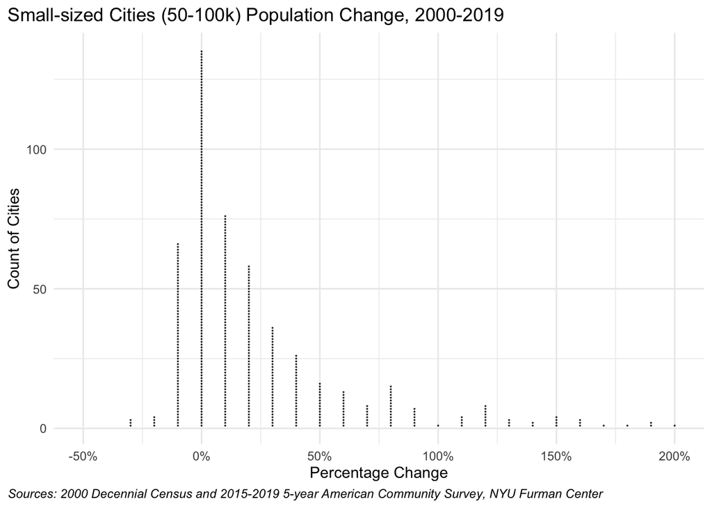

```r
# Pull and reorganize the data for the figure
all_city_comparison_viz <- all_city_comparison %>%
  select(geo_name, change, size_type) %>%
  group_by(size_type) %>%
  arrange(change) %>%
  mutate(change_rounded = (change - (change) %% 0.1)) %>%
  mutate(y = ave(change_rounded, change_rounded, FUN = seq_along)) %>%
  mutate(mean_change = 0.3378569) %>%
  drop_na(geo_name)

figure_1 <- ggplot(all_city_comparison_viz %>% filter(size_type == "small (50-100k)"), aes(x = change_rounded, y = y)) +
  geom_point(size = .01, alpha = .75) +
  scale_x_continuous(labels = scales::percent, breaks = pretty_breaks(), limits = c(-.5, 2)) +
  scale_y_continuous(breaks = pretty_breaks()) +
  labs(
    title = str_glue("Small-sized Cities (50-100k) Population Change, 2000-2019"),
    caption = str_glue("Sources: 2000 Decennial Census and 2015-2019 5-year American Community Survey, NYU Furman Center"),
    x = "Percentage Change",
    y = "Count of Cities",
    color = NULL
  ) +
  theme_minimal() +
  theme(
    plot.caption = element_text(hjust = 0, face = "italic"), # format the source caption
    plot.title.position = "plot",
    plot.caption.position = "plot"
  )

figure_1
```

## Change in Median Rent (2000-2019)

#### Prepare data for Figure 2: Change in Weighted Median Rent (2000-2019)

```r
##Pull 2000 decennial Census median rent figures
median_rent2000 <-
  fromJSON(paste0("https://api.census.gov/data/2000/dec/sf3?get=H063001,NAME&for=place:*&key=", census_api_key)) %>%
  as_tibble() %>%
  transmute(
    median_rent2000 = V1,
    geo_name = V2,
    geoid = str_glue("{V3}{V4}")
  ) %>%
  filter(median_rent2000 != "H063001")%>%
  mutate(
    median_rent2000 = as.numeric(median_rent2000)
  )

##Pull 2000 Decennial Census rental unit count figures
count_rent2000 <-
  fromJSON(paste0("https://api.census.gov/data/2000/dec/sf3?get=H062002,NAME&for=place:*&key=", census_api_key)) %>%
  as_tibble() %>%
  transmute(
    count_rent2000 = V1,
    geo_name = V2,
    geoid = str_glue("{V3}{V4}")
  ) %>%
  filter(count_rent2000 != "H062002")%>%
  mutate(
    count_rent2000 = as.numeric(count_rent2000)
  )

# Adjust for inflation using the CPi (The CPI is defined in "Define External Variables")
median_rent2000 <- median_rent2000 %>%
  mutate(median_rent2000_norm = CPI * median_rent2000)

## Join data
median_rents <- small_mid_city_pop_comparison %>%
  full_join(median_rent2000, by = "geoid") %>%
  full_join(count_rent2000, by = "geoid") %>%
  filter(size_type %in% c("mid (150-500k)", "small-mid (100-150k)", "small (50-100k)", "large (500k +)")) %>%
  transmute(
    geoid,
    pop_num,
    size_type,
    median_rent2000,
    median_rent2000_norm,
    rent_gross_med,
    count_rent2000,
    unit_rent_cash_num,
    agg_med_rent,
    agg_med_rent2000 = median_rent2000_norm * count_rent2000 # Create 2000 weighted median aggregate rent
  )

# create summary total
cities_median_rents <- median_rents %>%
  group_by(size_type) %>%
  summarise(
    pop_num = sum(pop_num),
    n = n(),
    median_rent2000 = median(median_rent2000, na.rm = TRUE),
    median_rent2000_norm = median(median_rent2000_norm, na.rm = TRUE),
    rent_gross_med = median(rent_gross_med, na.rm = TRUE),
    count_rent2000 = sum(count_rent2000, na.rm = TRUE),
    unit_rent_cash_num = sum(unit_rent_cash_num, na.rm = TRUE),
    agg_med_rent2000 = sum(agg_med_rent2000, na.rm = TRUE),
    agg_med_rent = sum(agg_med_rent, na.rm = TRUE)
  ) %>%
  ungroup()

#Select data for figure
chart_data_rent <- cities_median_rents %>%
  transmute(size_type,
    wgt_med_gross_rent2000 = agg_med_rent2000 / count_rent2000,
    wgt_med_gross_rent = agg_med_rent / unit_rent_cash_num
  )%>%mutate(
    wgt_med_gross_rent2000 = round(wgt_med_gross_rent2000, 0), #Round rent to integer
    wgt_med_gross_rent = round(wgt_med_gross_rent, 0) #Round rent to integer
  )


#Shape data for figure
chart_data_rent <- melt(chart_data_rent, id.vars = c("size_type"), measure.vars = c(
  "wgt_med_gross_rent2000",
  "wgt_med_gross_rent"
))

#format label
chart_data_rent <- chart_data_rent %>%
  mutate(variable = case_when(
    variable == "wgt_med_gross_rent2000" ~ "Weighted Median Rent 2000 ($)",
    variable == "wgt_med_gross_rent" ~ "Weighted Median Rent 2019 ($)"
  ))
```

#### Figure 2: Weighted Median Gross Rent (in 2019 Dollars), 2000 and 2015-19

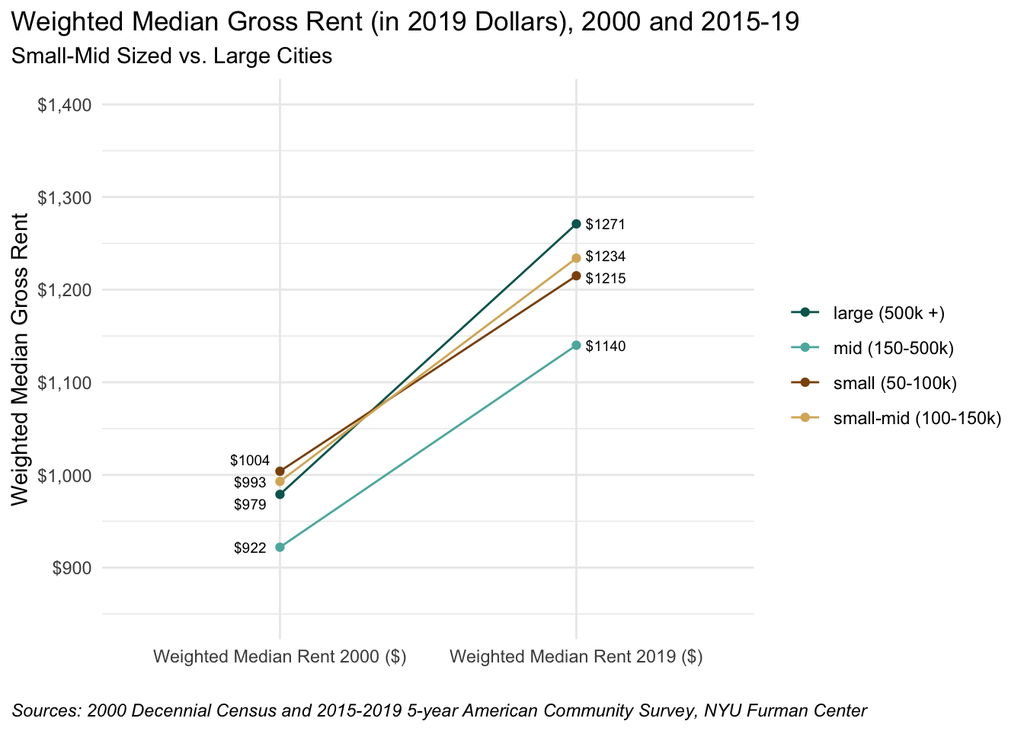

```r
## Median gross rents change figure
figure_2 <- ggplot(data = chart_data_rent, aes(x = variable, y = value, label = value, tooltip = value, group = size_type)) +
  geom_line(aes(color = size_type)) +
  geom_point(aes(color = size_type)) +
  geom_text_repel(data = chart_data_rent %>% filter(variable =="Weighted Median Rent 2000 ($)"),
                  aes(label = ifelse(value > 1, paste0("$", round(value, 0)), ""), y = value),
                  nudge_x = -0.1, size = 2.5, max.overlaps = Inf, box.padding = 0.2)  +
    geom_text_repel(data = chart_data_rent %>% filter(variable =="Weighted Median Rent 2019 ($)"),
                    aes(label = ifelse(value > 1, paste0("$", round(value, 0)), ""), y = value),
                    nudge_x = 0.1, size = 2.5, max.overlaps = Inf, box.padding = 0.2)  +
  scale_y_continuous(labels = scales::dollar_format(), breaks = pretty_breaks(), limits = c(850, 1400)) +
  scale_color_manual(values = c("#01665e", "#5ab4ac", "#8c510a", "#d8b365")) +
  theme_minimal() +
  labs(
    title = str_glue("Weighted Median Gross Rent (in 2019 Dollars), 2000 and 2015-19"),
    subtitle = "Small-Mid Sized vs. Large Cities",
    caption = str_glue("Sources: 2000 Decennial Census and 2015-2019 5-year American Community Survey, NYU Furman Center"),
    x = "",
    y = "Weighted Median Gross Rent",
    color = NULL
  ) +
  theme(
    plot.caption = element_text(hjust = 0, face = "italic"), # format the source caption
    plot.title.position = "plot",
    plot.caption.position = "plot"
  )

figure_2
```

## Rental Cost Burden by Income

#### Create data frame for Figure 3: rental housing cost burden rates by income group

```r
#Create summary data for Figure 3
cities_size_cost_burden <-
  small_mid_city_pop_comparison %>%
  group_by(size_type) %>%
  summarise(
    pop_num = sum(pop_num),
    n = n(),
    cost_burden_less20K_est = sum(cost_burden_less20K_est, na.rm = TRUE),
    count_less20K_est = sum(count_less20K_est, na.rm = TRUE),
    cost_burden_20K34k_est = sum(cost_burden_20K34k_est, na.rm = TRUE),
    count_20K34k_est = sum(count_20K34k_est, na.rm = TRUE),
    cost_burden_35K49k_est = sum(cost_burden_35K49k_est, na.rm = TRUE),
    count_35K49k_est = sum(count_35K49k_est, na.rm = TRUE),
    cost_burden_50K74k_est = sum(cost_burden_50K74k_est, na.rm = TRUE),
    count_50K74k_est = sum(count_50K74k_est, na.rm = TRUE),
    cost_burden_more75k_est = sum(cost_burden_more75k_est, na.rm = TRUE),
    count_more75k_est = sum(count_more75k_est, na.rm = TRUE)
  ) %>%
  ungroup() %>%
  mutate(cost_burden_less20K_rate = cost_burden_less20K_est / count_less20K_est,
         cost_burden_20K34k_rate = cost_burden_20K34k_est / count_20K34k_est,
         cost_burden_35K49k_rate = cost_burden_35K49k_est / count_35K49k_est,
         cost_burden_50K74k_rate = cost_burden_50K74k_est / count_50K74k_est,
         cost_burden_more75k_rate = cost_burden_more75k_est / count_more75k_est) %>%
  transmute(size_type, cost_burden_less20K_rate, cost_burden_20K34k_rate, cost_burden_35K49k_rate, cost_burden_50K74k_rate, cost_burden_more75k_rate)

#Select and shape data frame for figure
chart_data_burden <- melt(cities_size_cost_burden, id.vars = c("size_type"), measure.vars = c("cost_burden_less20K_rate", "cost_burden_20K34k_rate", "cost_burden_35K49k_rate", "cost_burden_50K74k_rate", "cost_burden_more75k_rate"))

#Rename variables
chart_data_burden <- chart_data_burden %>%
  mutate(variable = case_when(
    variable == "cost_burden_less20K_rate" ~ " Less than $20,000",
    variable == "cost_burden_20K34k_rate" ~ "$20,000 to $34,999",
    variable == "cost_burden_35K49k_rate" ~ "$35,000 to $49,999",
    variable == "cost_burden_50K74k_rate" ~ "$50,000 to $74,999",
    variable == "cost_burden_more75k_rate" ~ "$75,000 or more",
  ))
```

#### Figure 3: Share of Rental Housholds who are Housing Cost Burdened by Income, 2019

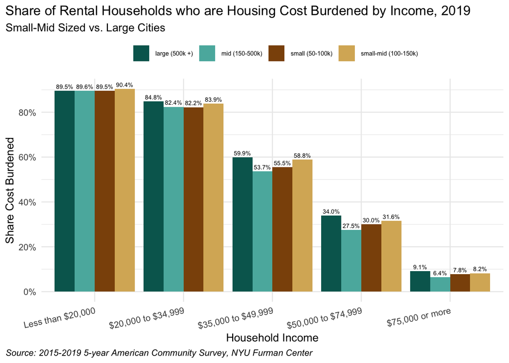

```r
figure_3 <- ggplot(chart_data_burden, aes(x = variable, y = value, fill = size_type, label = scales::percent(value, .1), tooltip = scales::percent(value, .1))) +
  geom_bar(stat = "identity", width = .9, position = "dodge") +
  geom_text(
    position = position_dodge(width = .9), # move to center of bars
    vjust = -0.5, # nudge above top of bar
    size = 2.1
  ) +
  scale_fill_manual(values = c("#01665e", "#5ab4ac", "#8c510a", "#d8b365")) +
  scale_y_continuous(labels = scales::percent, breaks = pretty_breaks()) +
  labs(
    title = str_glue("Share of Rental Households who are Housing Cost Burdened by Income, 2019"),
    subtitle = "Small-Mid Sized vs. Large Cities",
    caption = str_glue("Source: 2015-2019 5-year American Community Survey, NYU Furman Center"),
    x = "Household Income",
    y = "Share Cost Burdened",
    color = NULL
  ) +
  theme_minimal() +
  theme(
    axis.text.x = element_text(angle = 12, hjust = 1), # tilts the x-axis text
    legend.title = element_blank(),
    legend.text = element_text(size = 6),
    legend.position = "top",
    plot.caption = element_text(hjust = 0, face = "italic"), # format the source caption
    plot.title.position = "plot",
    plot.caption.position = "plot"
  )

figure_3
```

## Race and Homeownership

#### Create dataframe for Figure 4: Homeownership rate in 2019 by race and ethicity

```r
## Calculate estimates grouped by city size
cities_size_homeownership <-
  small_mid_city_pop_comparison %>%
  group_by(size_type) %>%
  summarise(
    pop_num = sum(pop_num),
    n = n(),
    homeowner_nonHisp_white_est = sum(homeowner_nonHisp_white_est),
    count_nonHisp_white_est = sum(count_nonHisp_white_est),
    homeowner_Black_est = sum(homeowner_Black_est),
    count_Black_est = sum(count_Black_est),
    homeowner_Asian_est = sum(homeowner_Asian_est),
    count_Asian_est = sum(count_Asian_est),
    homeowner_Latino_est = sum(homeowner_Latino_est),
    count_Latino_est = sum(count_Latino_est)
  ) %>%
  ungroup() %>%
  mutate(
    homeowner_rate_nonHisp_white = homeowner_nonHisp_white_est / count_nonHisp_white_est,
    homeowner_rate_Black = homeowner_Black_est / count_Black_est,
      homeowner_rate_Asian = homeowner_Asian_est / count_Asian_est,
      homeowner_rate_Latino = homeowner_Latino_est / count_Latino_est
  )

#Select summary stats for Figure 4
homeownership_2019_gg <- cities_size_homeownership %>%
  transmute(size_type, homeowner_rate_nonHisp_white, homeowner_rate_Black, homeowner_rate_Asian, homeowner_rate_Latino)

#Shape data frame for figure
chart_homeownership_2019 <- melt(homeownership_2019_gg, id.vars = c("size_type"), measure.vars = c("homeowner_rate_nonHisp_white", "homeowner_rate_Black", "homeowner_rate_Asian", "homeowner_rate_Latino"))

#Rename variables
chart_homeownership_2019 <- chart_homeownership_2019 %>%
  mutate(variable = case_when(
    variable == "homeowner_rate_nonHisp_white" ~ "Non-Hispanic white",
    variable == "homeowner_rate_Black" ~ "Black",
    variable == "homeowner_rate_Asian" ~ "Asian",
    variable == "homeowner_rate_Latino" ~ "Hispanic"
  ))
```

#### Figure 4: Homeownership Rates by Race and Ethnicity, 2019

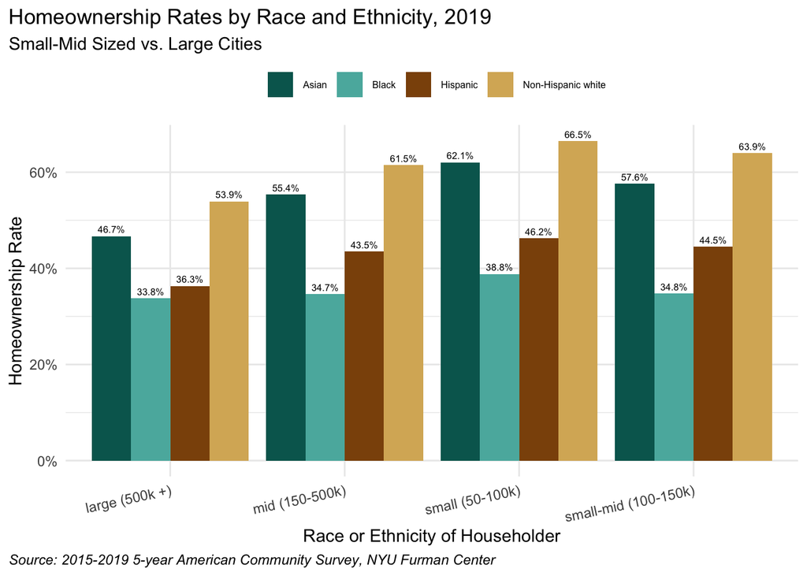

```r
figure_4 <- ggplot(chart_homeownership_2019, aes(size_type, value, label = scales::percent(value, .1), fill = factor(variable))) +
  geom_bar(stat = "identity", width = .9, position = "dodge") +
  geom_text(
    position = position_dodge(width = .9), # move text to center of bars
    vjust = -0.5, # nudge above top of bar
    size = 2.1
  ) +
  scale_fill_manual(values = c("#01665e", "#5ab4ac", "#8c510a", "#d8b365")) +
  scale_y_continuous(labels = scales::percent, breaks = pretty_breaks()) +
  labs(
    title = str_glue("Homeownership Rates by Race and Ethnicity, 2019"),
    subtitle = "Small-Mid Sized vs. Large Cities",
    caption = str_glue("Source: 2015-2019 5-year American Community Survey, NYU Furman Center"),
    x = "Race or Ethnicity of Householder",
    y = "Homeownership Rate",
    color = NULL
  ) +
  theme_minimal() +
  theme(
    axis.text.x = element_text(angle = 12, hjust = 1), # tilts the x-axis text
    legend.title = element_blank(),
    legend.text = element_text(size = 6),
    legend.position = "top",
    plot.caption = element_text(hjust = 0, face = "italic"), # format the source caption
    plot.title.position = "plot",
    plot.caption.position = "plot"
  )

figure_4
```

## Principal and Suburban Cities Summary

#### Create dataframe for Table 3

```r
## Creating a descriptive summary table for Suburbs/Principal cities
cities_size_stats_sub <-
  small_mid_city_pop_comparison %>%
  group_by(size_type, place_type) %>%
  summarise(
    total_population = sum(pop_num),
    n = n(),
    place_type_flag = mean(place_type_flag),
    pop_race_asian_num = sum(pop_race_asian_num),
    pop_race_black_num = sum(pop_race_black_num),
    pop_race_hisp_num = sum(pop_race_hisp_num),
    pop_race_white_num = sum(pop_race_white_num),
    pop_u18_num = sum(pop_u18_num),
    pop_65p_num = sum(pop_65p_num),
    pop_pov_num = sum(pop_pov_num),
    pop_pov_denom_num = sum(pop_pov_denom_num),
    unit_occ_num = sum(unit_occ_num),
    unit_occ_own_num = sum(unit_occ_own_num),
    unit_occ_rent_num = sum(unit_occ_rent_num),
    unit_rent_cash_num = sum(unit_rent_cash_num),
    rent_burden_num = sum(rent_burden_num),
    unit_num = sum(unit_num),
    unit_vac_num = sum(unit_vac_num),
    rent_burden_sev_num = sum(rent_burden_sev_num),
    rent_gross_den = sum(unit_rent_cash_num),
    hh_inc_agg = sum(aggregate_hh_income_est),
    hh_inc_den = sum(hh_income_count_est),
    agg_med_rent = sum(agg_med_rent),
    agg_med_hh_income = sum(agg_med_hh_income),
    total_units = sum(total_units),
    total_1_det = sum(total_1_det),
    total_1_att = sum(total_1_att),
    total_units_rent = sum(total_units_rent),
    units_rent_1_det = sum(units_rent_1_det),
    units_rent_1_att = sum(units_rent_1_att)
  ) %>%
  ungroup()%>%
  mutate(
  share_asian = pop_race_asian_num/total_population, #Share Asian,
  share_black = pop_race_black_num /total_population, #Share Black
  share_hisp = pop_race_hisp_num / total_population, #Share Hispanic
  share_white = pop_race_white_num /total_population, #Share white
  share_u18 = pop_u18_num / total_population, #Share under 18
  share_over_65 = pop_65p_num / total_population, #Share over 65
  share_poverty = pop_pov_num / pop_pov_denom_num, #Share Poverty
  share_owner_occ = unit_occ_own_num / unit_occ_num, #Share Owner-Occupied
  share_renter_occ = unit_occ_rent_num / unit_occ_num, #Share Renter Occupied
  share_vacancy = unit_vac_num / unit_num, #Vacancy rate
  share_rent_burden = rent_burden_num / unit_rent_cash_num, #Share Rent burdened
  share_sev_rent_burden = rent_burden_sev_num / unit_rent_cash_num, #Share Severely Rent burdened
  wgt_med_gross_rent = agg_med_rent / rent_gross_den,#Weighted median gross rent
  wgt_med_hh_income = agg_med_hh_income / hh_inc_den,#Weighted median household income
  share_total_1_det_att = (total_1_det + total_1_att)/ total_units,#share 1 unit detached and attached
  share_rent_1_det_att = (units_rent_1_det + units_rent_1_att)/ total_units_rent #share 1 unit rental detached and attached
  )%>% #Create new suburbs/Principal and city size indicator
  mutate(place_type_size = case_when(
    size_type == "large (500k +)" ~ "Principal - Large (500k+)",
    size_type == "mid (150-500k)" & place_type == "Principal" ~ "Principal - Mid (150-500k)",
    size_type == "mid (150-500k)" & place_type == "Suburbs" ~ "Suburbs - Mid (150-500k)",
    size_type == "small-mid (100-150k)" & place_type == "Principal" ~ "Principal - Small-mid (100-150k)",
    size_type == "small-mid (100-150k)" & place_type == "Suburbs" ~ "Suburbs - Small-mid (100-150k)",
    size_type == "small (50-100k)" & place_type == "Principal" ~ "Principal - Small (50-100k)",
    size_type == "small (50-100k)" & place_type == "Suburbs" ~ "Suburbs - Small (50-100k)"
  ))%>%
  transmute(total_population, n, share_asian, share_black, share_hisp, share_white, share_u18, share_over_65, share_poverty, wgt_med_hh_income, share_owner_occ, share_renter_occ, share_vacancy, share_rent_burden, share_sev_rent_burden, share_total_1_det_att, share_rent_1_det_att, wgt_med_gross_rent, place_type_size)
```

### Table 3: Select Population and Housing Characteristics by City Size Categories (Summary Statistics table)

```r
table_3 <- cities_size_stats_sub %>%
  pivot_longer(-place_type_size, names_to = "var", values_to = "val") %>%
  pivot_wider(names_from = place_type_size, values_from = val) %>%
  mutate(
    var_group = case_when(
      var %in% c("n", "total_population") ~ "Basic Stats",
      str_detect(var, "share_(asian|black|hisp|white)") ~ "Racial/Ethnic Composition",
      # Add more groups here
      var %in% c("share_u18", "share_over_65", "share_poverty", "wgt_med_hh_income") ~ "Age and Income",
      var %in% c("share_owner_occ", "share_renter_occ", "share_vacancy", "share_rent_burden", "share_sev_rent_burden", "share_total_1_det_att", "share_rent_1_det_att", "wgt_med_gross_rent") ~ "Housing Characteristics",
    ),
    var = recode(
      var,
      "n" = "Number of Cities",
      "total_population" = "Total Population",
      "place_type_flag" = "Core City (%)",
      "share_asian" = "Asian (%)",
      "share_black" = "Black (%)",
      "share_hisp" = "Hispanic (%)",
      "share_white" = "White (%)",
      "share_u18" = "Under 18 Years (%)",
      "share_over_65" = "65 Years or Older (%)",
      "share_poverty" = "Poverty (%)",
      "wgt_med_hh_income" = "Weighted Median Household Income ($)",
      "share_owner_occ" = "Owner-Occupied (%)",
      "share_renter_occ" = "Renter-Occupied (%)",
      "share_vacancy" = "Vacancy (%)",
      "share_rent_burden" = "Rent Burdened (%)",
      "share_sev_rent_burden" = "Severely Rent Burdened (%)",
      "share_total_1_det_att" = "Single-Family (1-Unit) Residence (%)",
      "share_rent_1_det_att" = "Single-Family (1-Unit) Rental (%)",
      "wgt_med_gross_rent" = "Weighted Median Gross Rent ($)",
    )
  ) %>%
  select(
    var, var_group,
    `Principal - Large (500k+)`, `Principal - Mid (150-500k)`, `Suburbs - Mid (150-500k)`, `Principal - Small-mid (100-150k)`, `Suburbs - Small-mid (100-150k)`, `Principal - Small (50-100k)`, `Suburbs - Small (50-100k)`
  ) %>%
  gt(rowname_col = "var", groupname_col = "var_group") %>%
  fmt_percent(columns = everything(), rows = str_detect(var, "(%)"), decimals = 1) %>%
  fmt_currency(columns = everything(), currency = "USD", rows = str_detect(var, "(Gross)|(Income)"), decimals = 0) %>%
  fmt_number(columns = everything(), rows = str_detect(var, "(Total)|(Number)"), decimals = 0) %>%
  tab_header(
    title = "Select Population and Housing Charteristics by City Size Categories, 2019",
  ) %>%
  tab_source_note("Sources: 2015-2019 5-year American Community Survey, NYU Furman Center")

table_3
```

Select Population and Housing Charteristics by City Size Categories, 2019

|  | Principal - Large (500k+) | Principal - Mid (150-500k) | Suburbs - Mid (150-500k) | Principal - Small-mid (100-150k) | Suburbs - Small-mid (100-150k) | Principal - Small (50-100k) | Suburbs - Small (50-100k) |
| --- | --- | --- | --- | --- | --- | --- | --- |
| Basic Stats |  |  |  |  |  |  |  |
| Total Population | 42,816,740 | 28,180,222 | 6,154,720 | 10,694,778 | 6,134,312 | 17,817,101 | 16,992,964 |
| Number of Cities | 34 | 108 | 32 | 88 | 52 | 252 | 250 |
| Racial/Ethnic Composition |  |  |  |  |  |  |  |
| Asian (%) | 9.5% | 6.6% | 11.8% | 7.9% | 8.6% | 6.8% | 8.5% |
| Black (%) | 20.5% | 19.5% | 10.4% | 14.8% | 10.1% | 12.3% | 10.3% |
| Hispanic (%) | 30.7% | 22.9% | 38.9% | 20.9% | 33.5% | 18.3% | 28.4% |
| White (%) | 35.9% | 47.0% | 35.1% | 52.7% | 44.0% | 58.7% | 49.3% |
| Age and Income |  |  |  |  |  |  |  |
| Under 18 Years (%) | 22.0% | 22.5% | 25.1% | 21.9% | 24.8% | 22.0% | 23.9% |
| 65 Years or Older (%) | 12.6% | 13.0% | 12.3% | 13.6% | 12.6% | 15.2% | 13.9% |
| Poverty (%) | 17.8% | 17.1% | 11.9% | 15.9% | 12.1% | 15.7% | 11.1% |
| Weighted Median Household Income ($) | $61,829 | $58,347 | $74,607 | $64,738 | $71,138 | $64,209 | $76,039 |
| Housing Characteristics |  |  |  |  |  |  |  |
| Owner-Occupied (%) | 44.5% | 50.7% | 60.3% | 53.2% | 59.7% | 55.9% | 62.7% |
| Renter-Occupied (%) | 55.5% | 49.3% | 39.7% | 46.8% | 40.3% | 44.1% | 37.3% |
| Vacancy (%) | 10.0% | 10.6% | 7.1% | 9.9% | 5.9% | 10.8% | 6.8% |
| Rent Burdened (%) | 49.8% | 49.8% | 52.7% | 50.2% | 52.9% | 49.2% | 50.7% |
| Severely Rent Burdened (%) | 25.6% | 25.2% | 26.0% | 25.8% | 25.9% | 25.1% | 25.0% |
| Single-Family (1-Unit) Residence (%) | 46.3% | 58.7% | 67.8% | 60.0% | 67.9% | 62.2% | 66.8% |
| Single-Family (1-Unit) Rental (%) | 21.1% | 30.1% | 37.4% | 29.5% | 33.9% | 31.8% | 31.7% |
| Weighted Median Gross Rent ($) | $1,271 | $1,101 | $1,402 | $1,198 | $1,315 | $1,125 | $1,336 |

Sources: 2015-2019 5-year American Community Survey, NYU Furman Center